# dge

Jordan A. Lee

2/28/2020 - 05 March, 2020

This is a html version of dge.R as of end of day 2/28/20

# Background

DESeq2 doesn’t actually use normalized counts, rather it uses the raw counts and models the normalization inside the Generalized Linear Model (GLM). These normalized counts will be useful for downstream visualization of results, but cannot be used as input to DESeq2 or any other tools that peform differential expression analysis which use the negative binomial model.

`DESeq()` details:

- Function runs: 1) est of size factors, est of dispersions, negative binomial generalized linear model (GLM) fitting and wald stats

`results()` details (these are outlined in the object printout below too):

- Adjusted pvals = BH corrected
- User specified alpha val to use for adjusted pval thresholding for FDR analysis
- Wald test to assess model fit (compared to likelihood ratio test). Wald test fits full model –> conducts tests for each gene to assess distance from 0 *- using the full model coefficent(s) and their standard error(s)* –> genes with coefficients significantly different than 0 will show this in their log2 fold change (and coefficient is reported as the log2fold change). - several studies have found that **Wald-log test** is better for RNA-seq data than others.

In RNA-seq data, larger variances grow with larger counts

# Analysis

```r
# Disclaimer: hardcoded names of patients in flat_matrix
# hard coded condition vector
####################
file_bulk1 <-'/Users/leejor/Ellrott_Lab/04_CSBC/cell-dissociation/data/01_process-bulkrna/07_ct_matrices/SCC_7319_B2_COUNTmatrix.txt'
file_bulk2 <-'/Users/leejor/Ellrott_Lab/04_CSBC/cell-dissociation/data/01_process-bulkrna/07_ct_matrices/SCC_7320_B2_COUNTmatrix.txt'
file_bulkGT1 <-'/Users/leejor/Ellrott_Lab/04_CSBC/cell-dissociation/data/01_process-bulkrna/07_ct_matrices/SCC_7319_GT_COUNTmatrix.txt'
file_bulkGT2 <-'/Users/leejor/Ellrott_Lab/04_CSBC/cell-dissociation/data/01_process-bulkrna/07_ct_matrices/SCC_7320_GT_COUNTmatrix.txt'
countsMECH_1_matrix_dir <- '/Users/leejor/Ellrott_Lab/04_CSBC/cell-dissociation/data/02_process-scrna/7319_Mech/'
countsENZ_1_matrix_dir <- '/Users/leejor/Ellrott_Lab/04_CSBC/cell-dissociation/data/02_process-scrna/7319_Enz/'
countsMECH_2_matrix_dir <- '/Users/leejor/Ellrott_Lab/04_CSBC/cell-dissociation/data/02_process-scrna/7320_Mech/'
countsENZ_2_matrix_dir <- '/Users/leejor/Ellrott_Lab/04_CSBC/cell-dissociation/data/02_process-scrna/7320_Enz/'
THRES = 0.1
output_sortedGenes = '/Users/leejor/Ellrott_Lab/04_CSBC/cell-dissociation/data/03_compare-bulk_scrna/scrna2bulk/geneOrdered_results.csv'

bulk_base_names <- c('bulk_7319', 'bulk_7320')
bulkgt_base_names <- c('bulkGT_7319', 'bulkGT_7320')
scmech_base_names <- c('sc_mech_7319', 'sc_mech_7320')
scenz_base_names <- c('sc_enz_7319', 'sc_enz_7320')
####################
```

```r
library(Seurat)
library(dplyr)
library(Matrix)
library(gdata)
library(DESeq2)
library(ggplot2)
library(pheatmap)
library(vsn)
library(RColorBrewer)
library(readr)
library(tibble)
library(tidyverse)
library(ggrepel)
```

# Create combined matrices of mech and enz

Read in files and create pseudo-bulk (take the sum of raw gene counts across all cell barcodes and report that as the pseudo-bulk gene count). Preprocessing steps shown in `.Rmd`

# Part 1. Establishing time and temp impact (bulk RNA-seq vs ground truth bulk RNA-seq)

```
## [1] "mean of normalized counts for all samples"
## [2] "log2 fold change (MLE): condition gt vs bulk"
## [3] "standard error: condition gt vs bulk"
## [4] "Wald statistic: condition gt vs bulk"
## [5] "Wald test p-value: condition gt vs bulk"
## [6] "BH adjusted p-values"
```

```
## [1] "MA plot of non-transformed counts"
```

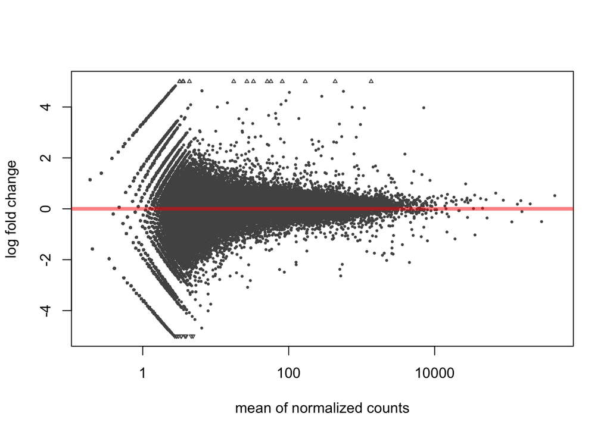

We can see that there are no signficantlly DE genes (would be denoted by red point).

# Part 2. Comparing scRNA-mech pseudo, scRNA-enz pseudo, and bulk - normalized

DGE analysis based on negative binomial distribution, mean and variance linked by local regression, can be implemented to estimate scale factors too. **Normalization method = DESeq2 median of ratios** which is the counts divided by sample size factors determined by meidan ratio of gene conts relative to geometric mean per gene - which accounts for seq depth and RNA composition. But not **gene length**

```
## [1] "mean of normalized counts for all samples"
## [2] "log2 fold change (MLE): condition mech vs bulk"
## [3] "standard error: condition mech vs bulk"
## [4] "Wald statistic: condition mech vs bulk"
## [5] "Wald test p-value: condition mech vs bulk"
## [6] "BH adjusted p-values"
```

```
## [1] "MA plot of normalized counts"
```

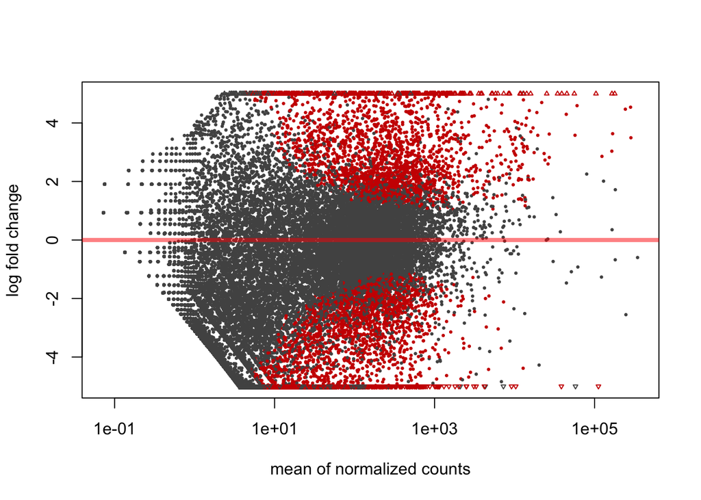

```
## [1] "Most differ expr genes of normalized counts"
```

```
##  [1] "ENSG00000077984" "ENSG00000102879" "ENSG00000105374" "ENSG00000110848"
##  [5] "ENSG00000111716" "ENSG00000111775" "ENSG00000115541" "ENSG00000117091"
##  [9] "ENSG00000126264" "ENSG00000127540" "ENSG00000134419" "ENSG00000161970"
## [13] "ENSG00000166136" "ENSG00000167286" "ENSG00000169442" "ENSG00000174886"
## [17] "ENSG00000176340" "ENSG00000186010" "ENSG00000196154" "ENSG00000211772"
## [21] "ENSG00000213741" "ENSG00000229117" "ENSG00000271503" "ENSG00000275302"
## [25] "ENSG00000276070"
```

Now let’s look at the log10(counts) of the data

```
## [1] "size factors applied for norm were:"
```

```
##    bulk_7319    bulk_7320 sc_mech_7319 sc_mech_7320  sc_enz_7319  sc_enz_7320
##    0.8068291    1.2407071    0.1806882    2.2188311    1.1771196    2.2952173
```

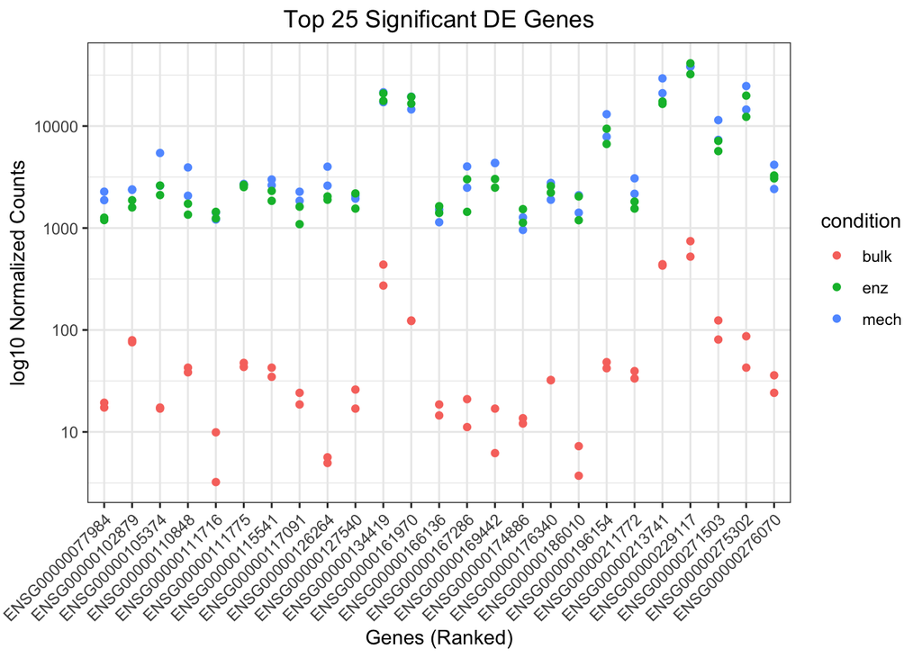

```
## [1] "Heatmap of all normalized counts"
```

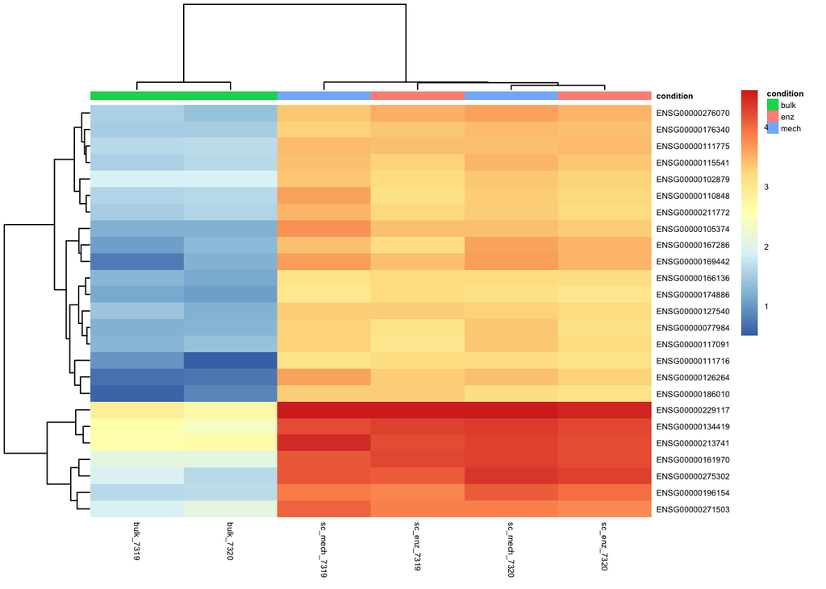

# Part 3. Comparing scRNA-mech pseudo vs bulk - normalized

```
## [1] "mean of normalized counts for all samples"
## [2] "log2 fold change (MLE): condition mech vs bulk"
## [3] "standard error: condition mech vs bulk"
## [4] "Wald statistic: condition mech vs bulk"
## [5] "Wald test p-value: condition mech vs bulk"
## [6] "BH adjusted p-values"
```

```
## [1] "MA plot of normalized counts"
```

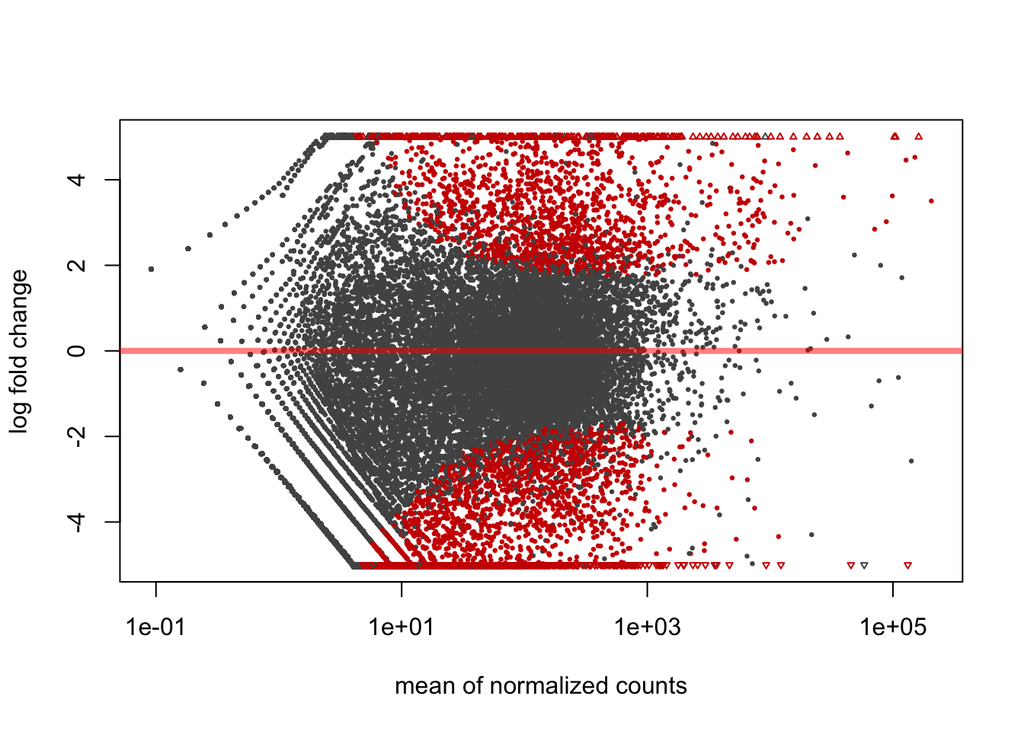

```
## [1] "Most differ expr genes of normalized counts"
```

```
##  [1] "ENSG00000077984" "ENSG00000105374" "ENSG00000111716" "ENSG00000117091"
##  [5] "ENSG00000124614" "ENSG00000126264" "ENSG00000127540" "ENSG00000145649"
##  [9] "ENSG00000161970" "ENSG00000167286" "ENSG00000169442" "ENSG00000186010"
## [13] "ENSG00000196154" "ENSG00000200087" "ENSG00000203865" "ENSG00000210082"
## [17] "ENSG00000211459" "ENSG00000213145" "ENSG00000241343" "ENSG00000263740"
## [21] "ENSG00000265401" "ENSG00000271503" "ENSG00000273149" "ENSG00000275302"
## [25] "ENSG00000276070" "ENSG00000276168"
```

Now let’s look at the log10(counts) of the data

```
## [1] "size factors applied for norm were:"
```

```
##    bulk_7319    bulk_7320 sc_mech_7319 sc_mech_7320
##     1.022126     1.577375     0.232577     2.737713
```

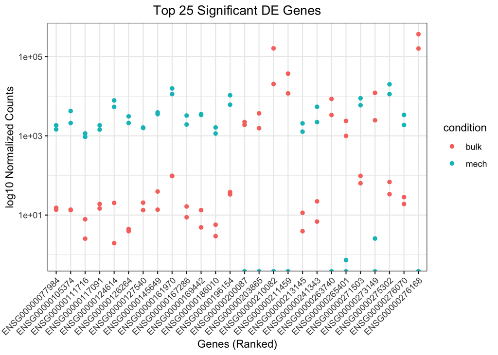

# Part 4. Comparing scRNA-enz pseudo vs bulk

```
## [1] "mean of normalized counts for all samples"
## [2] "log2 fold change (MLE): condition enz vs bulk"
## [3] "standard error: condition enz vs bulk"
## [4] "Wald statistic: condition enz vs bulk"
## [5] "Wald test p-value: condition enz vs bulk"
## [6] "BH adjusted p-values"
```

```
## [1] "MA plot of normalized counts"
```

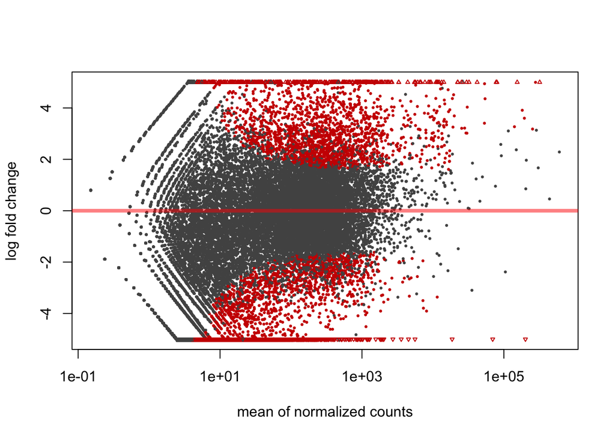

```
## [1] "Most differ expr genes of normalized counts"
```

```
##  [1] "ENSG00000105374" "ENSG00000124614" "ENSG00000126264" "ENSG00000157734"
##  [5] "ENSG00000161970" "ENSG00000167995" "ENSG00000169442" "ENSG00000173486"
##  [9] "ENSG00000174886" "ENSG00000186010" "ENSG00000196154" "ENSG00000200087"
## [13] "ENSG00000203865" "ENSG00000210082" "ENSG00000211459" "ENSG00000228022"
## [17] "ENSG00000241343" "ENSG00000257453" "ENSG00000263740" "ENSG00000265401"
## [21] "ENSG00000269968" "ENSG00000273149" "ENSG00000275302" "ENSG00000276070"
## [25] "ENSG00000276168"
```

Now let’s look at the log10(counts) of the data

```
## [1] "size factors applied for norm were:"
```

```
##   bulk_7319   bulk_7320 sc_enz_7319 sc_enz_7320
##   0.6670532   1.0525319   0.8816464   1.6574513
```

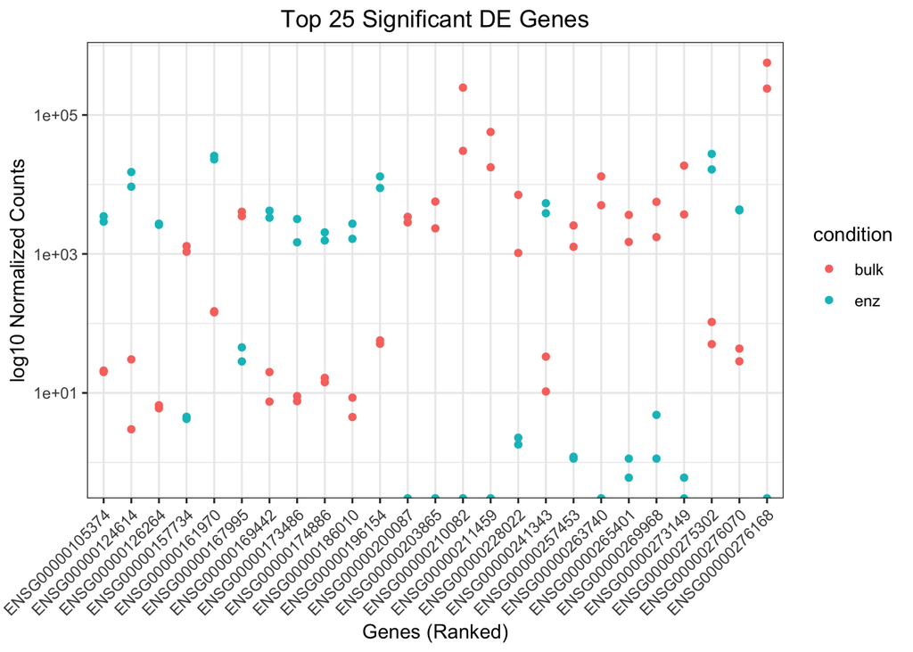